# Day 11

# Exam 1 Information

TBA

**Questions?**

**Goals for Today:**

1. Review lectures I & II for probability
2. Burn through several practice problems
3. Put probability topics into context

## Probability

### Probability Review & Bonus Material

**Why do we study probability in statistics?**

#### **Probability**

A number between $0$ and $1$ that tells us how *likely* a given “event” is to occur

Probability equal to $0$ means the event cannot occur

- $P(x)=0$

Probability equal to $1$ means the event must occur

- $P(x)=1$

Probability equal to $1/2$ means the event is as likely to occur as it is to not occur

- $P(x)=0.5$

**Probability close to 0 (but not equal to 0)** means the event is very unlikely to occur

- The event may still occur, but we’d tend to be surprised if it did

**Probability close to 1 (but not equal to 1)** means the event is very likely to occur

- The event may not occur, but we’d tend to be surprised if it didn’t

#### **Terminology**

**Experiment** (in context of probability):

- An activity that results in a definite outcome where the observed outcome is determined by chance

**Sample space:**

- The set of **ALL** possible outcomes of an experiment; denoted by $S$
1. Flip a coin once

$$S = \{H, T\}$$

2. Randomly select a person and then determine blood type

$$S = \{A, B, AB, O\}$$

*Event**

- A subset of outcomes belonging to sample space $S$
- A capital letter towards the beginning of the alphabet is used to denote an event
  - i.e. $A$, $B$, $C$, etc.
1. Suppose we flip a coin twice

$$S = \{HH, HT, TH, TT\}$$

2. Let $A$ be the event we observe at least one tails

$$A = \{HT, TH, TT\}$$

3. Let $B$ be the event we observe at most one tails

$$B = \{HH, HT, TH\}$$

**Simple event:** An event containing a single outcome in the sample space $S$

$$S = \{HH, HT, TH, TT\}$$

$A = \text{we observe two heads} = \{HH\}$

- **Simple event**

**Compound event:** An event formed by combining two or more events (thereby containing two or more outcomes in the sample space $S$)

$$S = \{HH, HT, TH, TT\}$$

$B = \text{we observe a head in the first or in the second flip} = \{HT, TH, HH\}$

- **Compound event**

#### **Probability Methods**

**Subjective Probability**

- Probability is assigned based on judgement or experience
- i.e. expert opinion, personal experience, “*vibe math*”

**Classical Probability**

- Make some **assumptions** in order to build a **mathematical model** from which we can **derive probabilities**
- It’s not *vibe math* but it can definitely *feel like it*

$$P(A) = \frac{\text{number of outcomes in event } A}{\text{total number of outcomes in } S}$$

**Relative or Empirical Probability**

- Think of the probability of an event as the **proportion of times that the event occurs**

$$P(x) \approx \frac{\text{number of times x is observed}}{\text{number of samples}}$$

#### **Law of Large Numbers**

- As the size of our sample (i.e., number of experiments) gets larger and larger:
- The relative frequency of the event of our interest gets closer and closer to the **true probability**

[figure not shown]

#### **Probability Models**

**Probability model:** Assigns a probability to each possible event constructed from the simple events in a particular sample space describing a particular experiment

For a finite sample space with $n$ simple events, e.g. $S = \{E_1, E_2, \dots, E_n\}$:

- The **probability model** assigns a number $p_i$ to event $E_i$ where $P(E_i) = p_i$ so that:

$$0 \leq p_i \leq 1$$

$$p_1 + p_2 + \dots + p_n = 1 \ \ \text{(as a consequence, }P(S) = 1\text{)}$$

For an **equally-likely** probability model, the probability of observing $E_i$ is:

$$P(E_i) = p_i = \frac{1}{n}$$

If $A$ is an event in an equally-likely sample space $S$ and contains $k$ outcomes, then:

$$P(A) = \frac{\text{No. of outcomes in } A}{\text{No. of outcomes in } S} = \frac{k}{n}$$

#### Complement Rule

$$P(A^c) = 1 - P(A) \quad \text{or} \quad P(A) = 1 - P(A^c)$$

This rule is useful when $P(A)$ is difficult to calculate but $P(A^c)$ is easy (or vice versa)

> Suppose there are $200$ potential blood donors, and their blood types are classified & counted in the table below:

$$\begin{array}{|c|c|c|c|c|c|}
\hline
\textbf{Blood Type} & \textbf{A} & \textbf{B} & \textbf{AB} & \textbf{O} & \textbf{Total} \\
\hline
\text{Count} & 80 & 20 & 10 & 90 & 200 \\
\hline
\end{array}$$

Our experiment involves selecting one donor and finding out what the blood type is

1. What is the sample space, $S$?
2. Build the probability model for this experiment:

$$\begin{array}{|c|c|c|c|c|c|}
\hline
\textbf{Blood Type} & \textbf{A} & \textbf{B} & \textbf{AB} & \textbf{O} & \textbf{Total} \\
\hline
\text{P(X=x)} & & & & & \\
\hline
\end{array}$$

3. **Let** $\text{O}=\{\text{Patient has Blood Type O}\}$, **find:**

$$P(\text{O}^c)$$

#### Unions and Intersections

The **union** of two events $A$ and $B$, denoted $A \cup B$, are all outcomes that belong to $A$, $B$, or both

- Saying $A \cup B$ is equivalent to saying “**A or B**”

The **intersection** of two events $A$ and $B$, denoted $A \cap B$, are all outcomes that belong to both $A$ and $B$

- Saying $A \cap B$ is equivalent to saying “**A and B**”

> In a statistics class of 30 students, there were 13 STEM majors and 17 Liberal Arts majors. Two of the STEM majors and three of the Liberal Arts majors received an A in this course. A student is chosen at random from the class:
1. Find the probability that the student is a Liberal Arts major
2. Find the probability that the student received an A
3. Find the probability that the student is a Liberal Arts major **or** received an A

#### Mutual Exclusivity

Two events $A$ and $B$ are **mutually exclusive** if they do not share any common outcomes

> You roll two, fair, six sided dice, one after the other:

**Let:**

$$\begin{array}{|c|c|}
\hline
\textbf{Event Name} & \textbf{Event Conditions} \\
\hline
\text{A} & \text{The sum of both dice is even}\\
\hline
\text{B} & \text{The first dice is 2}\\
\hline
\text{C} & \text{The second dice is odd}\\
\hline
\text{D} & \text{Both dice are the same number}\\
\hline
\end{array}$$

1. What are the possible outcomes of $B \cap C$?
2. What are the possible outcomes of $A \cap D$?
3. What are the possible outcomes of $B \cap C \cap D$?

#### Conditional Probability

A **conditional probability** of an event is a probability obtained with the **additional information** that some other event has already occurred

$P(A|B)$ denotes the conditional probability of event $A$ given that event $B$ has already occurred

$$P(A|B) = \frac{P(A \text{ and } B)}{P(B)}$$

$$P(A|B) = \frac{P(A \cap B)}{P(B)}$$

**Similarly:**

$$P(B|A) = \frac{P(A \text{ and } B)}{P(A)}$$

$$P(B|A) = \frac{P(A \cap B)}{P(A)}$$

> The below table shows the results from an experiment in which school children were given either $4$ quarters or a $\$1$ bill:

$$\begin{array}{|c|c|c|}
\hline
\textbf{} & \textbf{Purchased Gum} & \textbf{Kept the Money} \\
\hline
\text{Students Given Four Quarters} & 27 & 12 \\
\hline
{\text{Students Given a 1 Dollar Bill}} & 19 & 33 \\
\hline
\end{array}$$

Find the probability of randomly selecting a child who:

1. Spent the money, given that the student was given $4$ quarters
2. Kept the money, given that the student was given a $\$1$ bill

#### Multiplication Rule

Using the definition of **conditional probability:**

$$P(A|B) = \frac{P(A \cap B)}{P(B)},$$

We can do some simple algebra and find ourselves at the **multiplication rule**:

$$P(A \cap B) = P(A|B) P(B)$$

#### Independence

Events $A$ and $B$ are independent if the outcome of $A$ does not affect the outcome of $B$ and **vice versa**

In terms of **conditional probability:**

- The probability of $A$ does not change given $B$ happened and vice versa

That is, $A$ and $B$ are independent if one of the following is true:

$$P(A|B) = P(A)$$

$$P(B|A) = P(B)$$

$$P(A \cap B) = P(A)P(B)$$

**(You can show that all three statements are equivalent)**

#### Multiplication Rule for Independent Events

**Given:**

$$A \text{ and } B \Rightarrow \text{ Independent}$$

$$P(A \cap B) = P(A)P(B)$$

> A fair, six sided dice is rolled four times:

**What’s the probability that the sequence of rolls is** $1,\ 5, \ 2, \ 1$

> Let $M$ and $N$ be two events such that $P(M)=0.54$ and $P(N)=0.17$:
1. Find $P(M \cup N)$ given that $M$ and $N$ are **independent**
2. Find $P(M \cup N)$ given that $M$ and $N$ are **mutually exclusive**

**Questions?**

### Attendance QOTD

#### Notice on bonus material

> Do not take notes for the remainder of lecture. As a Gen Ed instructor, I have two tasks: (1) To arm you with the vital knowledge to make you diverse workers/scientists/etc. in the real world, and (2) To help those of you still unsure where you want to go in life decide whether my subject matter is something you’d like to dive further into.

> I would recommend those who still struggling with conditional probability **as a concept** to stay for the first part of this, beyond that this is complete optional.

## Concepts of Probability in Context

### Conditional Probability and Bayes’ Theorem

> During the COVID-19 pandemic, the masses became extremely familiar with viral antigen testing. These tests are chemically engineered in such a way that they minimize **false positives**, at the expense of allowing **false negatives** to be disproportionately high.

> In most, specialized, introductory statistics courses, student’s are taught to ellicit information from these false positive/negative rates using something called a “probability tree”. Today we’ll avoid that construct entirely and instead discuss the usage of conditional probabilities to achieve the same result.

**Bayes’ Theorem** provides us with a mathematical tool for using information about some outcome to determine it’s event (or vice versa), by rescaling the sample space using conditional probabilities.

**Given:**

$$A= \{\text{A student fails Exam 2}\}$$

$$B= \{\text{A student doesn't attend the Exam 2 Review}\}$$

**And:**

$$P(A)=0.08$$

- **Prior Probability**

$$P(B)=0.11$$

- **Marginal Probability**

$$P(B|A)=0.93$$

- **Likelihood of A given B if B is unchanging/determined**

**Bayes’ Rule states:**

$$P(A|B)={P(B|A)P(A) \over P(B)}$$

$$P(A|B)={0.93 * 0.08 \over 0.11} = 0.676$$

> The average COVID-19 antigen test is 99% sensitive and 80% specific, thus, the test will detect a **true positive** 99% of the time, and a **true negative** 80% of the time. Supposed that, after an outbreak, 0.7% of your dorm is sick with COVID. What is the probability that a randomly selected individual who tests negative isn’t actually sick?

**Let:**

$$A=\{\text{Individual is not sick}\}$$

$$B=\{\text{The test is negative}\}$$

We’re looking for $P(A|B)$, or the probability that an individual is not sick **given** that their test is negative

To apply Bayes’ Rule, we need a to fill in all of our blanks:

$$P(A)=0.993$$

$$P(B|A)=0.80$$

To find $P(A)$, we’ll need to apply the Law of Total Probability (something you have not, and will not be taught):

$$P(B)=P(B|A)P(A)+P(B|A^c)P(A^c)$$

Substituting in our new definition:

$$P(A|B)={P(B|A)P(A) \over P(B|A)P(A)+P(B|A^c)P(A^c)}$$

### Probabilistic Thinking

**When someone says there’s a 70/30 chance, what does that actually mean?**

Thinking in terms of probability is difficult, humans have trouble perceiving things outside of binary outcomes:

> The 1986 Space Shuttle Challenger experienced a catastrophic failure, causing it to break into pieces shortly into its flight.

The Challenger disaster was attributed to O-rings in the rocket boosters failing, resulting in the shuttle flying off axis and wobbling until it broke apart.

The launch team had done numerous tests and gathered $23$ data points:

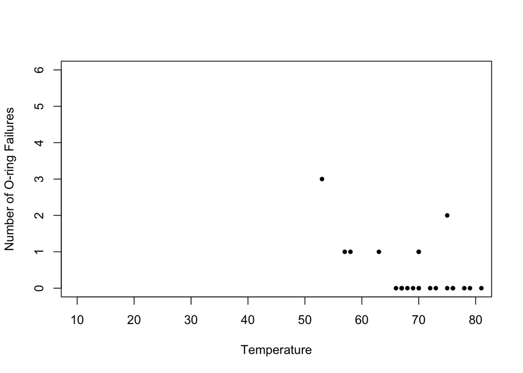

The team decided to **throw out** what they considered outliers in the data set.

> Remember: Outliers are only thrown out given that they’re seen as measurement errors. Abnormal data points that can’t be attributed exactly to a failed measurement should be kept, as they can tell you a lot about the reality of your data.

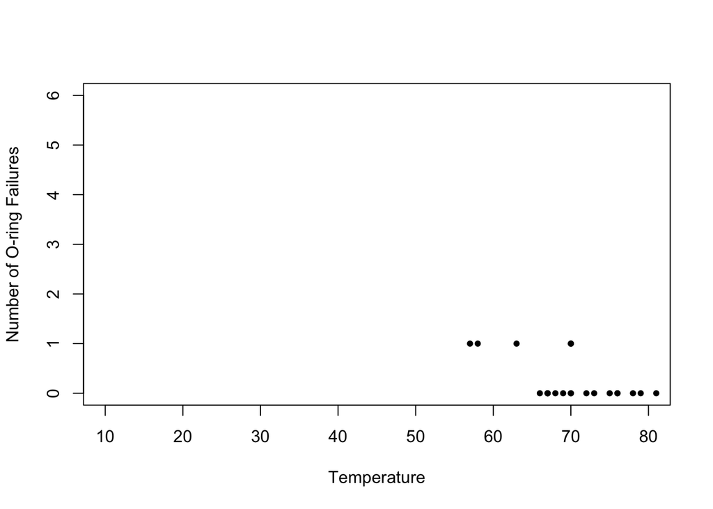

They likely performed a version of Least Squares Regression with their edited data:

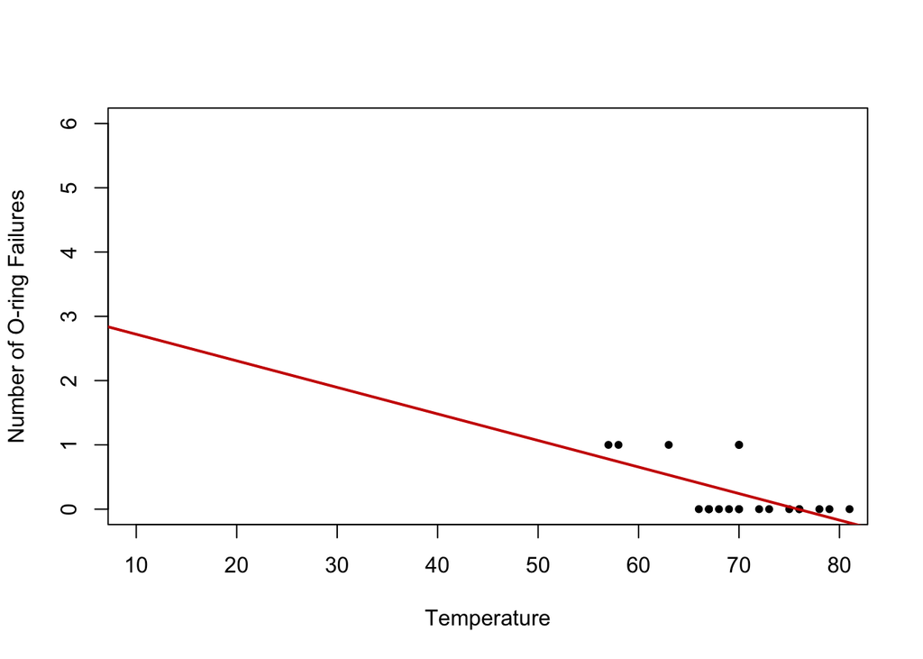

But when we **add the “outliers back in:**

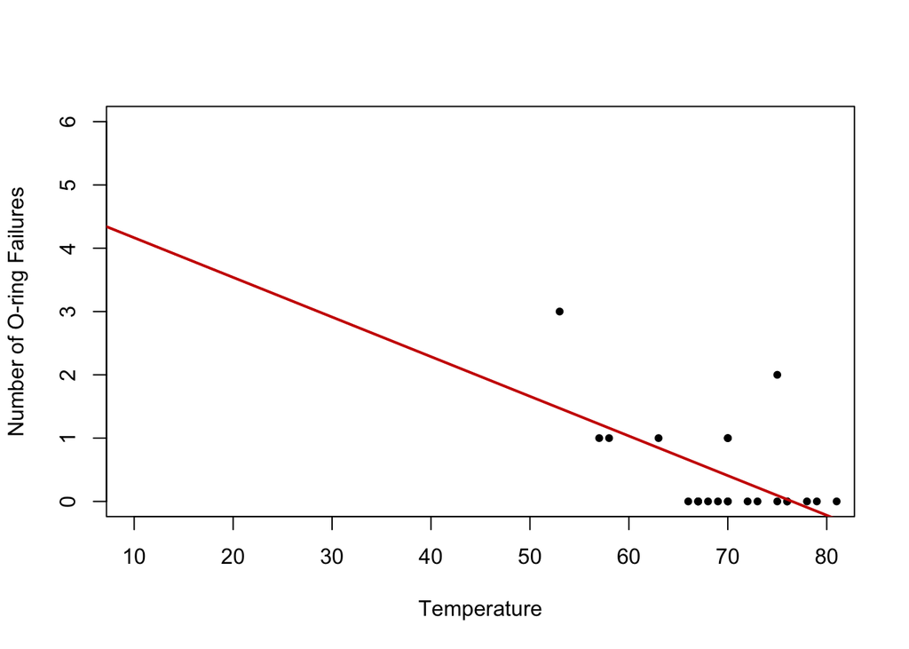

Science has advanced since that disaster, and now we can paint a more clear picture of just how doomed the flight was:

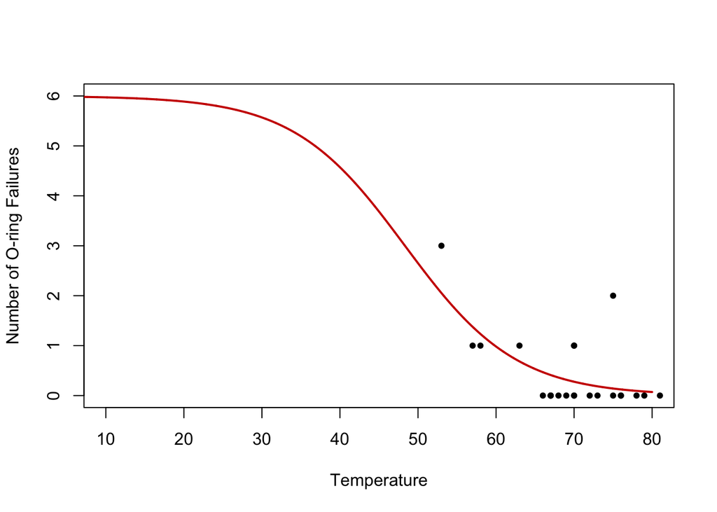

Probabilistic thinking is more than just recognizing whether something is a possibility or not. It’s about understanding the probability method that best describes the situation you’re assessing.

**In most cases, you can get away with looking at things from an empirical viewpoint**

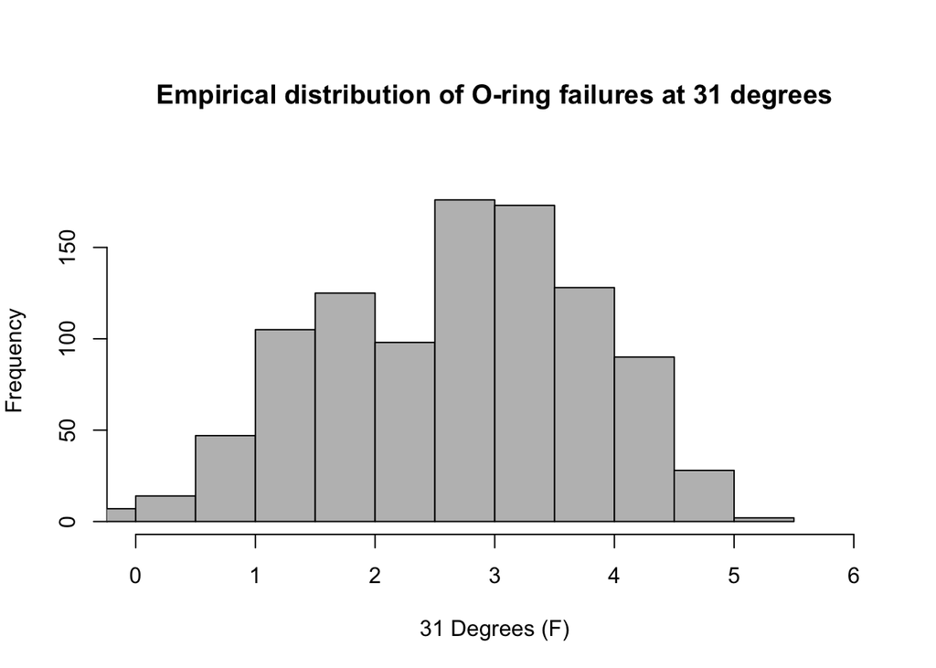

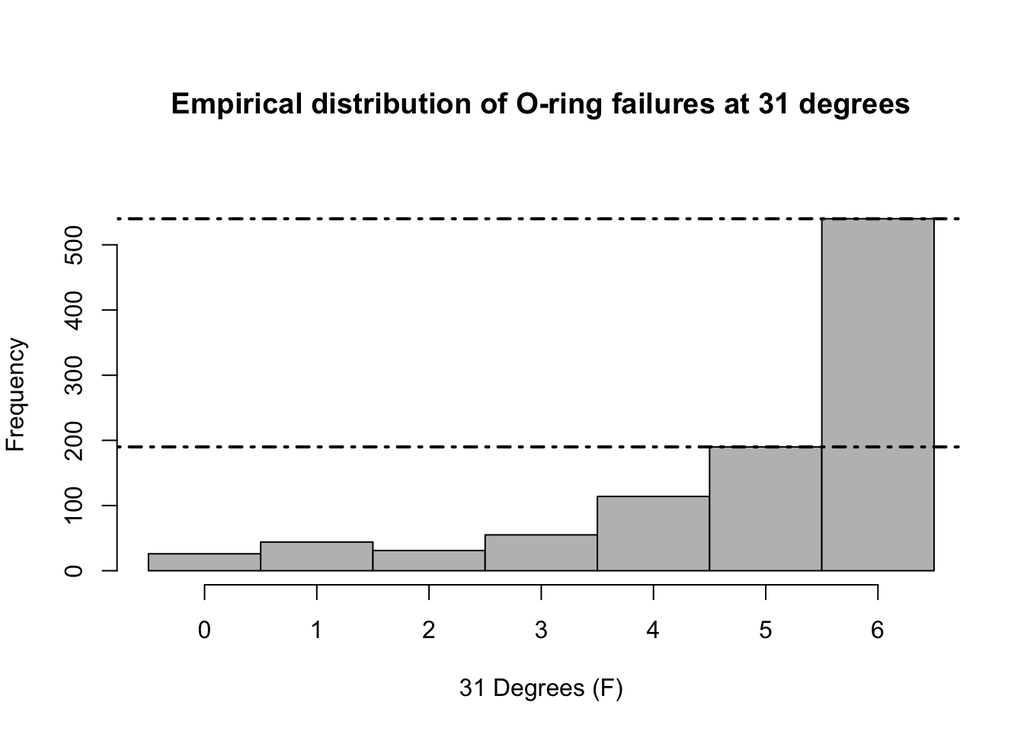